# Graphs

#### Main & Interaction effects of Scenario

> When answering questions (with either graph) in the axis scenario (M = 9.20, SD = 4.12), participants had significantly lower scores, t(316) = -4.77, p < 0.001, r = -.26, than in the longmire scenario (M = 10.52, SD = 2.97)

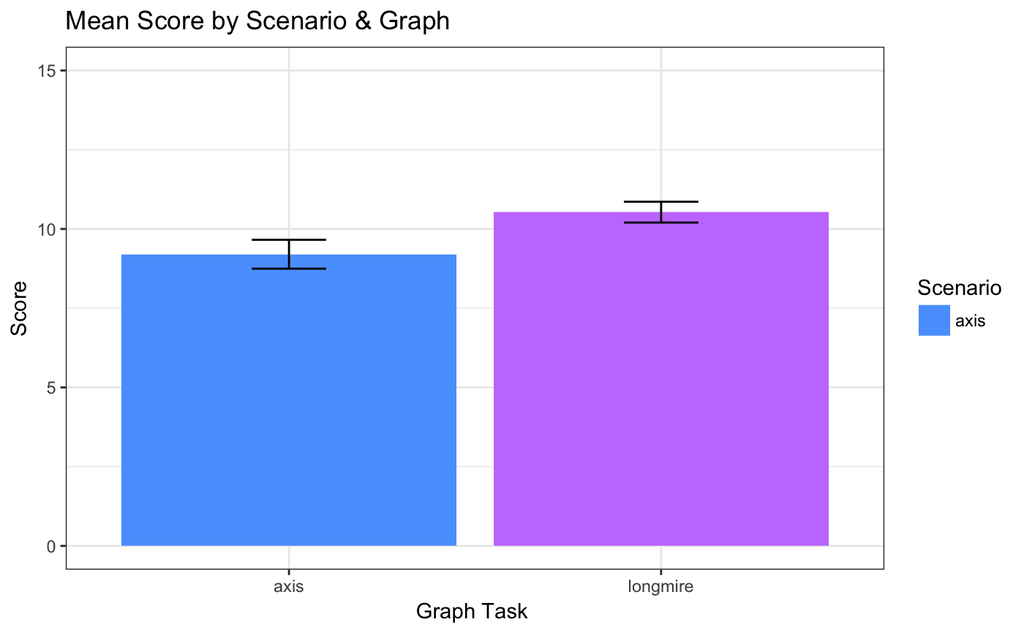

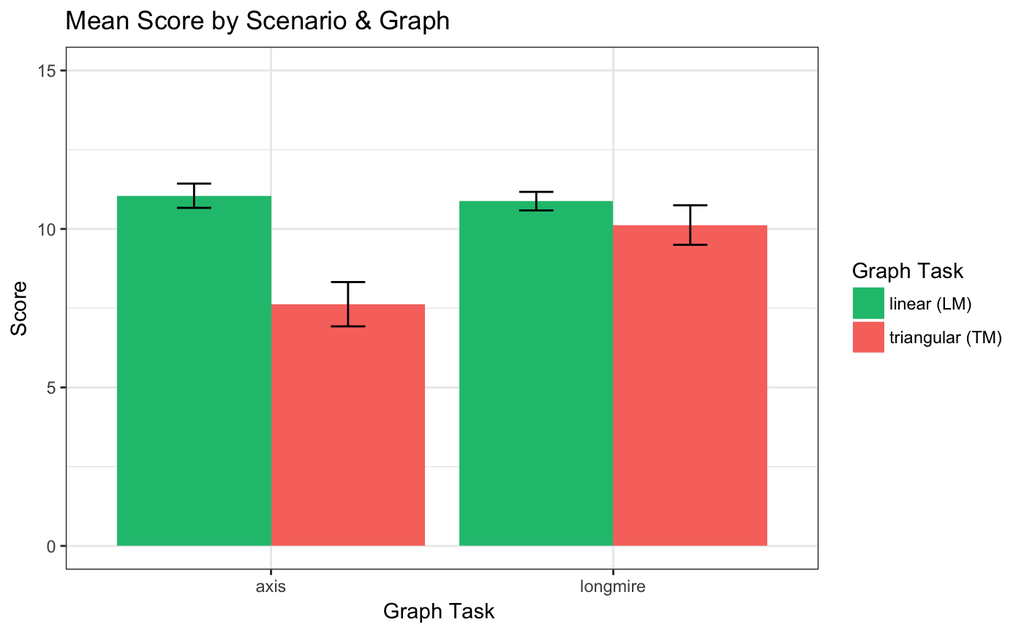

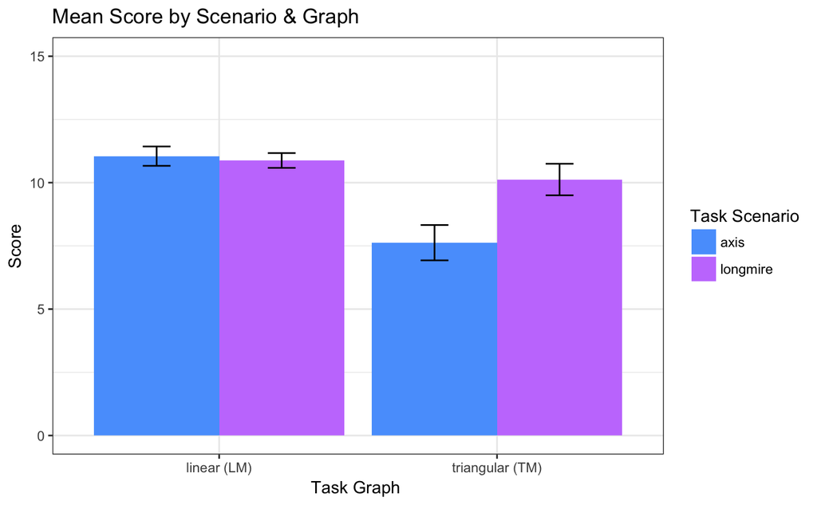

```
Ignoring unknown parameters: width
```

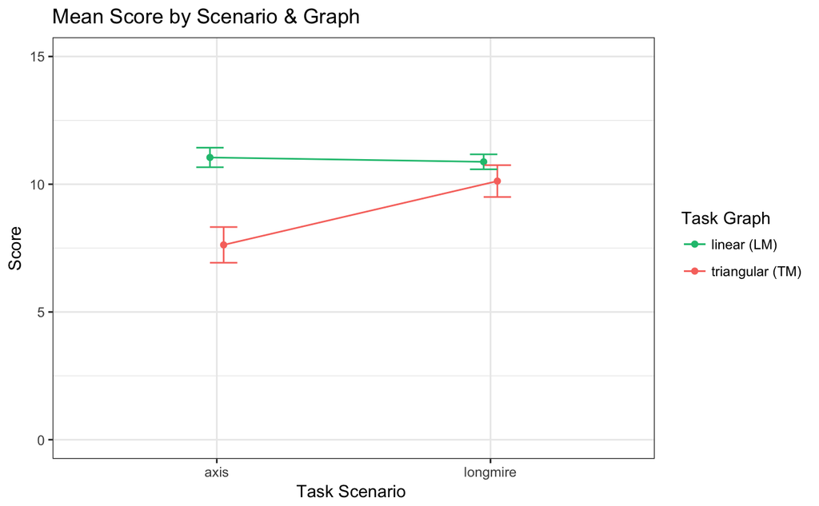

```
    Paired t-test

data:  value by scenario
t = -4.7692, df = 316, p-value = 2.829e-06
alternative hypothesis: true difference in means is not equal to 0
95 percent confidence interval:
 -1.8759649 -0.7801865
sample estimates:
mean of the differences
              -1.328076

[1] 0.259
```

When answering questions (with either graph) in the axis scenario (M = 9.20, SD = 4.12), participants had significantly lower scores, t(316) = -4.77, p < 0.001, r = -.26, than in the longmire scenario (M = 10.52, SD = 2.97)

| Group.1 | x |
| --- | --- |
| axis | 9.201893 |
| longmire | 10.529968 |

| Group.1 | x |
| --- | --- |
| axis | 4.118144 |
| longmire | 2.971896 |

#### Interaction of Graph & Order on Time

> no main effect of graph order. summary

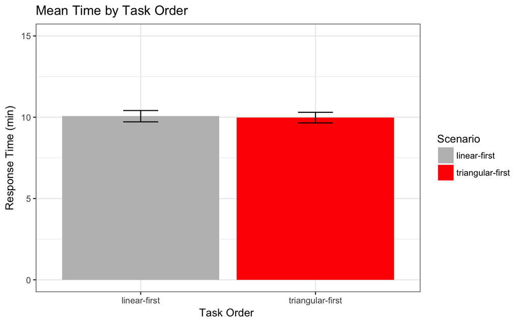

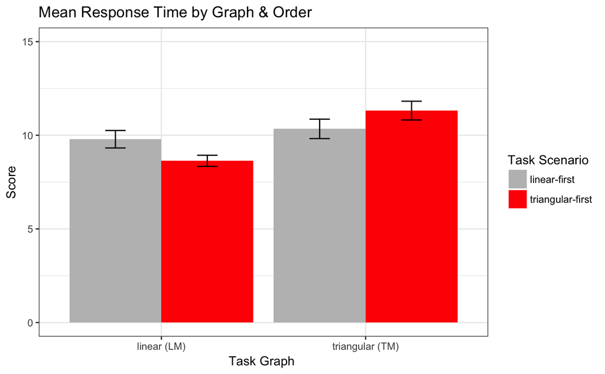

```
Ignoring unknown parameters: width
```

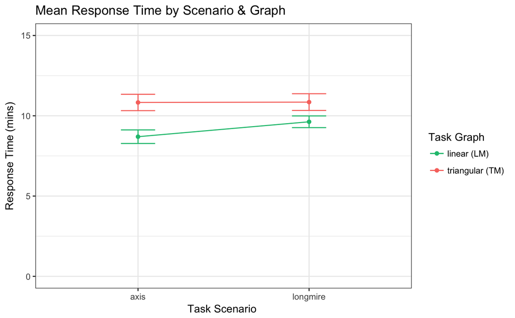